# Practice Activity 9.2 Multiclass Classification

Author

Shreya Vanaki

Our dataset consists of clinical data from patients who entered the hospital complaining of chest pain (“angina”) during exercise. The information collected includes:

- `age` : Age of the patient
- `sex` : Sex of the patient
- `cp` : Chest Pain type
  - Value 0: asymptomatic
  - Value 1: typical angina
  - Value 2: atypical angina
  - Value 3: non-anginal pain
- `trtbps` : resting blood pressure (in mm Hg)
- `chol` : cholesterol in mg/dl fetched via BMI sensor
- `restecg` : resting electrocardiographic results
  - Value 0: normal
  - Value 1: having ST-T wave abnormality (T wave inversions and/or ST elevation or depression of > 0.05 mV)
  - Value 2: showing probable or definite left ventricular hypertrophy by Estes’ criteria
- `thalach` : maximum heart rate achieved during exercise
- `output` : the doctor’s diagnosis of whether the patient is at risk for a heart attack
  - 0 = not at risk of heart attack
  - 1 = at risk of heart attack

```python
# library imports
import pandas as pd
import numpy as np
from sklearn.pipeline import Pipeline
from sklearn.neighbors import KNeighborsClassifier
from sklearn.tree import DecisionTreeClassifier
from sklearn.linear_model import LogisticRegression
from sklearn.linear_model import LinearRegression
from sklearn.preprocessing import StandardScaler, OneHotEncoder, PolynomialFeatures
from sklearn.discriminant_analysis import LinearDiscriminantAnalysis
from sklearn.model_selection import GridSearchCV, cross_val_predict
from sklearn.compose import make_column_selector, ColumnTransformer
from sklearn.tree import export_graphviz
from IPython.display import display, Image
import graphviz
from sklearn.model_selection import train_test_split, cross_val_score
from sklearn.preprocessing import PolynomialFeatures
from sklearn.metrics import classification_report, roc_auc_score, roc_curve, auc
from sklearn.metrics import confusion_matrix, accuracy_score, precision_score, recall_score, f1_score, roc_auc_score, accuracy_score
from sklearn.preprocessing import label_binarize
import matplotlib.pyplot as plt
from sklearn.tree import plot_tree
```

```python
ha = pd.read_csv("https://www.dropbox.com/s/aohbr6yb9ifmc8w/heart_attack.csv?dl=1")
```

## Q1: Natural Multiclass Models

Fit a multiclass KNN, Decision Tree, and LDA for the heart disease data; this time predicting the type of chest pain (categories 0 - 3) that a patient experiences. For the decision tree, plot the fitted tree, and interpret the first couple splits.

## KNN

```python
# Converting vars into categorical
ha['cp'] = ha['cp'].astype('category')
ha['sex'] = ha['sex'].astype('category')
ha['restecg'] = ha['restecg'].astype('category')
ha['output'] = ha['output'].astype('category')
X = ha.drop(['cp'], axis=1)
y = ha['cp']
```

```python
ct = ColumnTransformer(
  [
    ("dummify", OneHotEncoder(sparse_output = False, handle_unknown='ignore'),
    make_column_selector(dtype_include=object)),
    ("standardize", StandardScaler(),
    make_column_selector(dtype_include=np.number))
  ],
  remainder = "passthrough"
)
```

```python
knn_model = Pipeline(steps=[("knn", KNeighborsClassifier())])

knn__n_neighbors =range(1, 21)

param_grid = {'knn__n_neighbors': range(1, 21)}

# Create GridSearchCV object
grid_search = GridSearchCV(knn_model, param_grid, cv=5, scoring='accuracy')  # You can adjust the scoring method as needed

# Fit the model
grid_knn = grid_search.fit(X, y)
results = grid_knn.cv_results_['mean_test_score']


# Get the best parameters and the best model
best_params = grid_knn.best_params_
best_knn_model = grid_knn.best_estimator_

print(best_params)

pd.DataFrame(data = {"alpha": knn__n_neighbors, "scores": results}).sort_values(by="scores", ascending = False)
```

```
{'knn__n_neighbors': 19}
```

|  | alpha | scores |
| --- | --- | --- |
| 18 | 19 | 0.472391 |
| 9 | 10 | 0.457912 |
| 12 | 13 | 0.457710 |
| 6 | 7 | 0.454209 |
| 19 | 20 | 0.454007 |
| 17 | 18 | 0.454007 |
| 4 | 5 | 0.450909 |
| 2 | 3 | 0.450505 |
| 8 | 9 | 0.450505 |
| 16 | 17 | 0.446734 |
| 13 | 14 | 0.446734 |
| 5 | 6 | 0.443367 |
| 10 | 11 | 0.443232 |
| 11 | 12 | 0.443030 |
| 15 | 16 | 0.439327 |
| 1 | 2 | 0.435825 |
| 3 | 4 | 0.432593 |
| 7 | 8 | 0.432391 |
| 14 | 15 | 0.428485 |
| 0 | 1 | 0.380875 |

```python
best_knn_accuracy = cross_val_score(best_knn_model, X, y, cv=5, scoring='accuracy').mean()

# Fit the final model
best_knn_model.fit(X, y)

print("Best KNN Model:", best_knn_model)
print("Best Cross-Validated Accuracy Score:", best_knn_accuracy)
```

```
Best KNN Model: Pipeline(steps=[('knn', KNeighborsClassifier(n_neighbors=19))])
Best Cross-Validated Accuracy Score: 0.4723905723905724
```

```python
y_probs_knn = best_knn_model.predict_proba(X)

# Calculate ROC AUC for each class and take the average
knn_auc = roc_auc_score(y, y_probs_knn, multi_class='ovr', average='macro')

knn_auc
```

```
0.7263694461475678
```

## Decision Tree

```python
# Create a preprocessing pipeline
ct = ColumnTransformer(
  [
    ("dummify", OneHotEncoder(sparse_output = False, handle_unknown='ignore'),
    make_column_selector(dtype_include=object)),
    ("standardize", StandardScaler(),
    make_column_selector(dtype_include=np.number))
  ],
  remainder = "passthrough"
)

# Create the Decision Tree model pipeline
dt_model = Pipeline(steps=[
    ('transform', ct),
    ('dt', DecisionTreeClassifier())
])

# Define the parameter grid
param = {'dt__max_depth': [1,2, 3, 4, 5, 6, 7, 8, 9, 10]}

# Create a GridSearchCV object
gscv = GridSearchCV(dt_model, param, cv=5, scoring='accuracy')

# Fit the GridSearchCV object to your data
gscv_fitted = gscv.fit(X, y)
results = gscv_fitted.cv_results_['mean_test_score']

# Get the best parameters and best F1 score
best_params = gscv_fitted.best_params_
best_accuracy = gscv_fitted.best_score_
best_dt_model = gscv.best_estimator_

print("Best Parameters:", best_params)
print("Best Accuracy Score:", best_accuracy)
```

```
Best Parameters: {'dt__max_depth': 1}
Best Accuracy Score: 0.5752188552188552
```

```python
y_probs_dt = best_dt_model.predict_proba(X)

# Calculate ROC AUC for each class and take the average
dt_auc = roc_auc_score(y, y_probs_dt, multi_class='ovr', average='macro')

dt_auc
```

```
0.5736886654876444
```

```python
best_dt = best_dt_model.named_steps['dt']  # Extract the Decision Tree model from the pipeline
feature_importances = best_dt.feature_importances_

features = X.columns
print("Feature Importances:", feature_importances)
print(features)
```

```
Feature Importances: [0. 0. 0. 0. 0. 0. 1.]
Index(['age', 'sex', 'trtbps', 'chol', 'restecg', 'thalach', 'output'], dtype='object')
```

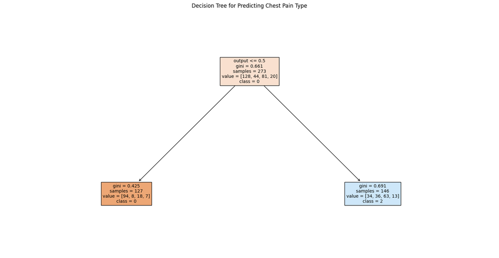

```python
# Plot the fitted Decision Tree
plt.figure(figsize=(20,10))
plot_tree(best_dt, filled=True, feature_names=features, class_names=['0', '1', '2', '3'], fontsize=10)
plt.title('Decision Tree for Predicting Chest Pain Type')
plt.show()
```

## LDA

```python
lda_model = Pipeline(steps=[
    ('transform', ct),
    ('lda', LinearDiscriminantAnalysis())
])

# cross-validated accuracy
cross_val_accuracy = cross_val_score(lda_model, X, y, cv=5, scoring='accuracy')

# Calculate the mean accuracy across folds
mean_accuracy = cross_val_accuracy.mean()

mean_accuracy

print("Accuracy Score:", mean_accuracy)
```

```
Accuracy Score: 0.4724579124579124
```

## Q2: OvR

Create a new column in the `ha` dataset called `cp_is_3`, which is equal to `1` if the `cp` variable is equal to `3` and `0` otherwise.

Then, fit a Logistic Regression to predict this new target, and report the **F1 Score**.

Repeat for the other three `cp` categories. Which category was the OvR approach best at distinguishing?

```python
def check_cp(row):
    if row['cp'] == 3:
        return 1
    else:
        return 0

ha['cp_is_3'] = ha.apply(check_cp, axis=1)
ha.head()
```

|  | age | sex | cp | trtbps | chol | restecg | thalach | output | cp_is_3 |
| --- | --- | --- | --- | --- | --- | --- | --- | --- | --- |
| 0 | 63 | 1 | 3 | 145 | 233 | 0 | 150 | 1 | 1 |
| 1 | 37 | 1 | 2 | 130 | 250 | 1 | 187 | 1 | 0 |
| 2 | 56 | 1 | 1 | 120 | 236 | 1 | 178 | 1 | 0 |
| 3 | 57 | 0 | 0 | 120 | 354 | 1 | 163 | 1 | 0 |
| 4 | 57 | 1 | 0 | 140 | 192 | 1 | 148 | 1 | 0 |

```python
X_lr = ha.drop(['cp', 'cp_is_3'], axis=1)  # Features excluding 'cp' and 'cp_is_3'
y_lr = ha['cp_is_3']  # New target variable 'cp_is_3'

# Create and fit the Logistic Regression model
logistic_model = Pipeline(steps=[("transform", ct), ("logistic", LogisticRegression())])
logistic_model.fit(X_lr, y_lr)

param_grid = {'logistic__C': [0.01, 0.1, 1, 10, 100]}
grid_search = GridSearchCV(logistic_model, param_grid, cv=5, scoring='f1_macro')
grid_search.fit(X_lr, y_lr)

# Best parameters and model
best_params = grid_search.best_params_
best_logistic_model = grid_search.best_estimator_
best_log_f1_score = cross_val_score(best_logistic_model, X, y, cv=5, scoring='f1_macro').mean()

best_logistic_model.fit(X, y)

print("Best Logistic Regression Model:", best_logistic_model)
print("Best Cross-Validated F1 Score:", best_log_f1_score)
```

```
Best Logistic Regression Model: Pipeline(steps=[('transform',
                 ColumnTransformer(transformers=[('scaler', StandardScaler(),
                                                  [0, 1])])),
                ('logistic', LogisticRegression(C=0.01))])
Best Cross-Validated F1 Score: 0.1573587999748337
```

```python
def check_cp(row):
    if row['cp'] == 2:
        return 1
    else:
        return 0

ha['cp_is_2'] = ha.apply(check_cp, axis=1)
ha.head()
```

[output not shown]

```python
X_lr = ha.drop(['cp', 'cp_is_3', 'cp_is_2'], axis=1)
y_lr = ha['cp_is_2']  # New target variable 'cp_is_2'

# Create and fit the Logistic Regression model
logistic_model = Pipeline(steps=[("transform", ct), ("logistic", LogisticRegression())])
logistic_model.fit(X_lr, y_lr)

param_grid = {'logistic__C': [0.01, 0.1, 1, 10, 100]}
grid_search = GridSearchCV(logistic_model, param_grid, cv=5, scoring='f1_macro')
grid_search.fit(X_lr, y_lr)

# Best parameters and model
best_params = grid_search.best_params_
best_logistic_model = grid_search.best_estimator_
best_log_f1_score = cross_val_score(best_logistic_model, X, y, cv=5, scoring='f1_macro').mean()

best_logistic_model.fit(X, y)

print("Best Logistic Regression Model:", best_logistic_model)
print("Best Cross-Validated F1 Score:", best_log_f1_score)
```

```
Best Logistic Regression Model: Pipeline(steps=[('transform',
                 ColumnTransformer(transformers=[('scaler', StandardScaler(),
                                                  [0, 1])])),
                ('logistic', LogisticRegression(C=1))])
Best Cross-Validated F1 Score: 0.2218102333459219
```

```python
def check_cp(row):
    if row['cp'] == 1:
        return 1
    else:
        return 0

ha['cp_is_1'] = ha.apply(check_cp, axis=1)
ha.head()
```

|  | age | sex | cp | trtbps | chol | restecg | thalach | output | cp_is_3 | cp_is_2 | cp_is_1 |
| --- | --- | --- | --- | --- | --- | --- | --- | --- | --- | --- | --- |
| 0 | 63 | 1 | 3 | 145 | 233 | 0 | 150 | 1 | 1 | 0 | 0 |
| 1 | 37 | 1 | 2 | 130 | 250 | 1 | 187 | 1 | 0 | 1 | 0 |
| 2 | 56 | 1 | 1 | 120 | 236 | 1 | 178 | 1 | 0 | 0 | 1 |
| 3 | 57 | 0 | 0 | 120 | 354 | 1 | 163 | 1 | 0 | 0 | 0 |
| 4 | 57 | 1 | 0 | 140 | 192 | 1 | 148 | 1 | 0 | 0 | 0 |

```python
X_lr = ha.drop(['cp', 'cp_is_3', 'cp_is_2', 'cp_is_1'], axis=1)
y_lr = ha['cp_is_1']  # New target variable 'cp_is_1'

# Create and fit the Logistic Regression model
logistic_model = Pipeline(steps=[("transform", ct), ("logistic", LogisticRegression())])
logistic_model.fit(X_lr, y_lr)

param_grid = {'logistic__C': [0.01, 0.1, 1, 10, 100]}
grid_search = GridSearchCV(logistic_model, param_grid, cv=5, scoring='f1_macro')
grid_search.fit(X_lr, y_lr)

# Best parameters and model
best_params = grid_search.best_params_
best_logistic_model = grid_search.best_estimator_
best_log_f1_score = cross_val_score(best_logistic_model, X, y, cv=5, scoring='f1_macro').mean()

best_logistic_model.fit(X, y)

print("Best Logistic Regression Model:", best_logistic_model)
print("Best Cross-Validated F1 Score:", best_log_f1_score)
```

```
Best Logistic Regression Model: Pipeline(steps=[('transform',
                 ColumnTransformer(transformers=[('scaler', StandardScaler(),
                                                  [0, 1])])),
                ('logistic', LogisticRegression(C=0.01))])
Best Cross-Validated F1 Score: 0.1573587999748337
```

```python
def check_cp(row):
    if row['cp'] == 0:
        return 1
    else:
        return 0

ha['cp_is_0'] = ha.apply(check_cp, axis=1)
ha.head()
```

|  | age | sex | cp | trtbps | chol | restecg | thalach | output | cp_is_3 | cp_is_2 | cp_is_1 | cp_is_0 |
| --- | --- | --- | --- | --- | --- | --- | --- | --- | --- | --- | --- | --- |
| 0 | 63 | 1 | 3 | 145 | 233 | 0 | 150 | 1 | 1 | 0 | 0 | 0 |
| 1 | 37 | 1 | 2 | 130 | 250 | 1 | 187 | 1 | 0 | 1 | 0 | 0 |
| 2 | 56 | 1 | 1 | 120 | 236 | 1 | 178 | 1 | 0 | 0 | 1 | 0 |
| 3 | 57 | 0 | 0 | 120 | 354 | 1 | 163 | 1 | 0 | 0 | 0 | 1 |
| 4 | 57 | 1 | 0 | 140 | 192 | 1 | 148 | 1 | 0 | 0 | 0 | 1 |

```python
X_lr = ha.drop(['cp', 'cp_is_3', 'cp_is_2', 'cp_is_1', 'cp_is_0'], axis=1)
y_lr = ha['cp_is_0']  # New target variable 'cp_is_2'

# Create and fit the Logistic Regression model
logistic_model = Pipeline(steps=[("transform", ct), ("logistic", LogisticRegression())])
logistic_model.fit(X_lr, y_lr)

param_grid = {'logistic__C': [0.01, 0.1, 1, 10, 100]}
grid_search = GridSearchCV(logistic_model, param_grid, cv=5, scoring='f1_macro')
grid_search.fit(X_lr, y_lr)

# Best parameters and model
best_params = grid_search.best_params_
best_logistic_model = grid_search.best_estimator_
best_log_f1_score = cross_val_score(best_logistic_model, X, y, cv=5, scoring='f1_macro').mean()

best_logistic_model.fit(X, y)

print("Best Logistic Regression Model:", best_logistic_model)
print("Best Cross-Validated F1 Score:", best_log_f1_score)
```

```
Best Logistic Regression Model: Pipeline(steps=[('transform',
                 ColumnTransformer(transformers=[('scaler', StandardScaler(),
                                                  [0, 1])])),
                ('logistic', LogisticRegression(C=1))])
Best Cross-Validated F1 Score: 0.2218102333459219
```

## Q3: OvO

Reduce your dataset to only the `0` and `1` types of chest pain.

Then, fit a Logistic Regression to predict between the two groups, and report the **ROC-AUC**.

Repeat comparing category `0` to `2` and `3`. Which pair was the OvO approach best at distinguishing?

### Chest Pain Types: 0 and 1

```python
# reduced dataset
ha_filtered = ha.drop(['cp', 'cp_is_3', 'cp_is_2'], axis=1)

#defining X and y
X = ha_filtered.drop(['cp_is_1', 'cp_is_0'], axis=1)
y = ha_filtered['cp_is_1']

# Create and fit the Logistic Regression model
logistic_model = Pipeline(steps=[("transform", ct), ("logistic", LogisticRegression())])
logistic_model.fit(X, y)

param_grid = {'logistic__C': [0.01, 0.1, 1, 10, 100]}
grid_search = GridSearchCV(logistic_model, param_grid, cv=5, scoring='roc_auc_ovo')
grid_search.fit(X_lr, y_lr)

# Best parameters and model
best_params = grid_search.best_params_
best_logistic_model = grid_search.best_estimator_
y_probs_log = best_logistic_model.predict_proba(X)[:, 1]  # Probability for the positive class

best_logistic_model.fit(X, y)

# Calculating the ROC-AUC score
best_roc_auc_score = roc_auc_score(y, y_probs_log)

best_logistic_model.fit(X, y)

print("Best Logistic Regression Model:", best_logistic_model)
print("Best Cross-Validated ROC-AUC Score:", best_roc_auc_score)
```

```
Best Logistic Regression Model: Pipeline(steps=[('transform',
                 ColumnTransformer(transformers=[('scaler', StandardScaler(),
                                                  [0, 1])])),
                ('logistic', LogisticRegression(C=1))])
Best Cross-Validated ROC-AUC Score: 0.4088924176260421
```

```python
# reduced dataset
ha_filtered = ha.drop(['cp', 'cp_is_3', 'cp_is_2'], axis=1)

#defining X and y
X = ha_filtered.drop(['cp_is_1', 'cp_is_0'], axis=1)
y = ha_filtered['cp_is_0']

# Create and fit the Logistic Regression model
logistic_model = Pipeline(steps=[("transform", ct), ("logistic", LogisticRegression())])
logistic_model.fit(X, y)

param_grid = {'logistic__C': [0.01, 0.1, 1, 10, 100]}
grid_search = GridSearchCV(logistic_model, param_grid, cv=5, scoring='roc_auc_ovo')
grid_search.fit(X_lr, y_lr)

# Best parameters and model
best_params = grid_search.best_params_
best_logistic_model = grid_search.best_estimator_
y_probs_log = best_logistic_model.predict_proba(X)[:, 1]  # Probability for the positive class

best_logistic_model.fit(X, y)

# Calculating the ROC-AUC score
best_roc_auc_score = roc_auc_score(y, y_probs_log)

best_logistic_model.fit(X, y)

print("Best Logistic Regression Model:", best_logistic_model)
print("Best Cross-Validated ROC-AUC Score:", best_roc_auc_score)
```

```
Best Logistic Regression Model: Pipeline(steps=[('transform',
                 ColumnTransformer(transformers=[('scaler', StandardScaler(),
                                                  [0, 1])])),
                ('logistic', LogisticRegression(C=1))])
Best Cross-Validated ROC-AUC Score: 0.6059536637931033
```

### Chest Pain Types: 0 and 2

```python
# Assuming 'ha' is your DataFrame and 'ct' is your ColumnTransformer
# Reduced dataset
ha_filtered = ha.drop(['cp', 'cp_is_1', 'cp_is_3'], axis=1)

# Defining X and y
X = ha_filtered.drop(['cp_is_2', 'cp_is_0'], axis=1)
y = ha_filtered['cp_is_2']

# Create and fit the Logistic Regression model
logistic_model = Pipeline(steps=[("transform", ct), ("logistic", LogisticRegression())])

# Define the parameter grid and GridSearchCV
param_grid = {'logistic__C': [0.01, 0.1, 1, 10, 100]}
grid_search = GridSearchCV(logistic_model, param_grid, cv=5, scoring='roc_auc')
grid_search.fit(X, y)

# Best parameters and model from GridSearchCV
best_logistic_model = grid_search.best_estimator_

# Best Cross-Validated ROC-AUC Score
best_roc_auc = cross_val_score(best_logistic_model, X, y, cv=5, scoring='roc_auc').mean()

# Final fitting of the best model
best_logistic_model.fit(X, y)

print("Best Logistic Regression Model:", best_logistic_model)
print("Best Cross-Validated ROC-AUC Score:", best_roc_auc)
```

```
Best Logistic Regression Model: Pipeline(steps=[('transform',
                 ColumnTransformer(transformers=[('scaler', StandardScaler(),
                                                  [0, 1])])),
                ('logistic', LogisticRegression(C=0.01))])
Best Cross-Validated ROC-AUC Score: 0.5865379653885845
```

```python
# reduced dataset
ha_filtered = ha.drop(['cp', 'cp_is_1', 'cp_is_3'], axis=1)

#defining X and y
X = ha_filtered.drop(['cp_is_2', 'cp_is_0'], axis=1)
y = ha_filtered['cp_is_0']

# Create and fit the Logistic Regression model
logistic_model = Pipeline(steps=[("transform", ct), ("logistic", LogisticRegression())])
logistic_model.fit(X, y)

param_grid = {'logistic__C': [0.01, 0.1, 1, 10, 100]}
grid_search = GridSearchCV(logistic_model, param_grid, cv=5, scoring='roc_auc')
grid_search.fit(X_lr, y_lr)

# Best parameters and model from GridSearchCV
best_logistic_model = grid_search.best_estimator_

# Best Cross-Validated ROC-AUC Score
best_roc_auc = cross_val_score(best_logistic_model, X, y, cv=5, scoring='roc_auc').mean()

# Final fitting of the best model
best_logistic_model.fit(X, y)

print("Best Logistic Regression Model:", best_logistic_model)
print("Best Cross-Validated ROC-AUC Score:", best_roc_auc)
```

```
Best Logistic Regression Model: Pipeline(steps=[('transform',
                 ColumnTransformer(transformers=[('scaler', StandardScaler(),
                                                  [0, 1])])),
                ('logistic', LogisticRegression(C=1))])
Best Cross-Validated ROC-AUC Score: 0.572949602122016
```

### Chest Pain Types: 0 and 3

```python
# reduced dataset
ha_filtered = ha.drop(['cp', 'cp_is_1', 'cp_is_2'], axis=1)

#defining X and y
X = ha_filtered.drop(['cp_is_3', 'cp_is_0'], axis=1)
y = ha_filtered['cp_is_3']

# Create and fit the Logistic Regression model
logistic_model = Pipeline(steps=[("transform", ct), ("logistic", LogisticRegression())])
logistic_model.fit(X, y)

param_grid = {'logistic__C': [0.01, 0.1, 1, 10, 100]}
grid_search = GridSearchCV(logistic_model, param_grid, cv=5, scoring='roc_auc')
grid_search.fit(X_lr, y_lr)

# Best parameters and model from GridSearchCV
best_logistic_model = grid_search.best_estimator_

# Best Cross-Validated ROC-AUC Score
best_roc_auc = cross_val_score(best_logistic_model, X, y, cv=5, scoring='roc_auc').mean()

# Final fitting of the best model
best_logistic_model.fit(X, y)

print("Best Logistic Regression Model:", best_logistic_model)
print("Best Cross-Validated ROC-AUC Score:", best_roc_auc)
```

```
Best Logistic Regression Model: Pipeline(steps=[('transform',
                 ColumnTransformer(transformers=[('scaler', StandardScaler(),
                                                  [0, 1])])),
                ('logistic', LogisticRegression(C=1))])
Best Cross-Validated ROC-AUC Score: 0.45999999999999996
```

```python
# reduced dataset
ha_filtered = ha.drop(['cp', 'cp_is_1', 'cp_is_2'], axis=1)

#defining X and y
X = ha_filtered.drop(['cp_is_3', 'cp_is_0'], axis=1)
y = ha_filtered['cp_is_0']

# Create and fit the Logistic Regression model
logistic_model = Pipeline(steps=[("transform", ct), ("logistic", LogisticRegression())])
logistic_model.fit(X, y)

param_grid = {'logistic__C': [0.01, 0.1, 1, 10, 100]}
grid_search = GridSearchCV(logistic_model, param_grid, cv=5, scoring='roc_auc')
grid_search.fit(X_lr, y_lr)

# Best parameters and model from GridSearchCV
best_logistic_model = grid_search.best_estimator_

# Best Cross-Validated ROC-AUC Score
best_roc_auc = cross_val_score(best_logistic_model, X, y, cv=5, scoring='roc_auc').mean()

# Final fitting of the best model
best_logistic_model.fit(X, y)

print("Best Logistic Regression Model:", best_logistic_model)
print("Best Cross-Validated ROC-AUC Score:", best_roc_auc)
```

```
Best Logistic Regression Model: Pipeline(steps=[('transform',
                 ColumnTransformer(transformers=[('scaler', StandardScaler(),
                                                  [0, 1])])),
                ('logistic', LogisticRegression(C=1))])
Best Cross-Validated ROC-AUC Score: 0.572949602122016
```

ROC-AUC scores for the Logistic Regression model for each pair of chest pain categories:

Category 0 vs Category 1: ROC-AUC = 0.408 Category 0 vs Category 2: ROC-AUC = 0.58 Category 0 vs Category 3: ROC-AUC = 0.46